# posc: Probability of Outcome Superiority Curves in R

26 October 2026

# Summary

A correlation coefficient says how strongly a predictor is related to an outcome. It does not say what the relationship means for a choice between two people. Suppose that a rehabilitation program has one place and two eligible patients. Patient A scores 34 on a prognostic score and patient B scores 22. In a validation study of 100 earlier patients, the score correlated 0.52 with recovery. The standard deviation of the score was 10. The clinician wants the probability that patient A, the higher scorer, will recover better. A probability of outcome superiority curve (POSC) gives that probability as a function of the difference between the two people on the predictor. The curve equals 0.5 when the two people have the same score and moves away from 0.5 as the difference grows. For the two patients, who differ by 12 points, it gives patient A a probability of about 0.70 of the better recovery.

`posc` is an R package (R Core Team 2026) that computes, plots and compares these curves. A curve can be computed from a published correlation and sample size, from a correlation matrix for a weighted composite of several predictors, from a fitted linear model, or directly from raw data without assuming a distribution. Each curve comes with a confidence band and with print, summary, predict and plot methods.

# Statement of need

Common language effect sizes express an effect as a probability so that a reader without statistical training can interpret it. The original version is the probability of superiority for two groups (McGraw and Wong 1992; Grissom 1994; Vargha and Delaney 2000), the probability that a randomly chosen member of one group scores higher than a randomly chosen member of the other. Dunlap (1994) extended the idea to a correlation between two continuous variables. His statistic is the probability that, of two randomly chosen people, the one with the higher predictor score also has the higher outcome. Under bivariate normality it equals $1/2 + \arcsin(\rho)/\pi$, so a correlation of 0.50 corresponds to a probability of 0.67.

A single number is not enough for a decision between two specific people, because the probability depends on how far apart they are. The clinician in the example knows both scores, as does a hiring committee that compares two applicants. When the two scores are close, the probability that the higher scorer has the better outcome is close to 0.5. When they are far apart, it can be far from 0.5. Under bivariate normality with correlation $\rho$ and predictor standard deviation $\sigma_X$, the curve is
$$\theta(\Delta) =
\Phi\!\left(\frac{\rho\,\Delta}{\sigma_X\sqrt{2(1-\rho^2)}}\right),$$
where $\Delta$ is the difference between the two people on the predictor and $\Phi$ is the standard normal distribution function. Dunlap’s statistic is the average of this curve over the distribution of $\Delta$. For $\rho = 0.50$ the curve gives 0.66 at a difference of one standard deviation and 0.79 at two. Two populations can share the same average of 0.67 and have different curves.

# State of the field

Several R packages compute the probability of superiority for group differences, among them `effectsize` (Ben-Shachar, Lüdecke, and Makowski 2020), which also reports related indices such as Cohen’s $U_3$. For correlations, Li and Waisman (2019) proposed the probability of bivariate superiority, a single-number estimate related to Dunlap’s statistic. In clinical research the concordance index (Harrell et al. 1982), available in `Hmisc` and `survival`, summarizes how often a prognostic model orders two patients correctly. For a continuous outcome it is Dunlap’s statistic with the model prediction as the predictor, again as a single number. None of these tools computes the probability as a function of the difference between the two people.

A dedicated package suits the curve better than an addition to a general effect-size package. The curve is a function, not a number, so it needs its own object, a confidence band, a prediction method and a plot. The empirical estimator adds a spline model, a bootstrap and binned diagnostics.

# Software design

Four constructors build a curve. `posc_uni()` takes a correlation and a sample size and computes the normal-theory curve with a confidence band from the Fisher transformation. `posc_multi()` takes a correlation matrix and computes the curve for the optimally weighted composite of several predictors. `posc_lm()` does the same for the fitted values of a model estimated with `lm()`. Both use the adjusted multiple correlation by default. `posc_emp()` takes raw predictor and outcome scores. It forms pairs of observations, records for each pair whether the person higher on the predictor is also higher on the outcome, and fits a spline logistic regression of that indicator on the difference. Each constructor returns an object of class `"posc"` that holds the curve on a symmetric grid of differences, the quantities it was computed from, and a prediction function that evaluates the curve and its interval at any difference and any confidence level. The constructors differ only in how they build the prediction function, so one set of methods serves all four types of curve. `print()`, `summary()` and `predict()` report probabilities with confidence limits at default or chosen differences, `as.data.frame()` returns the grid, and `plot()` and `autoplot()` draw the curve with `ggplot2` (Wickham 2016) as an object that the user can modify. `posc_comp()` overlays two or more curves and tests whether their correlations differ. `posc_bins()` returns the binned proportions of an empirical curve as a table.

Three design choices in `posc_emp()` follow from the properties of the curve. First, because the two people are exchangeable, every POSC satisfies $\theta(0) = 0.5$ and $\theta(-\Delta) = 1 - \theta(\Delta)$. The estimator models the logit of the curve as $\operatorname{sign}(\Delta)\,g(|\Delta|)$, where $g$ is a natural cubic spline with no intercept whose basis is zero at a difference of zero, with `df = 3` by default. Both properties then hold for every fit. A spline fitted without the constraint could cross 0.5 away from zero, or give two different answers for the same pair depending on which person is listed first.

Second, pairs that share a person are not independent, because each person appears in $n - 1$ pairs. Standard errors from the pairwise logistic regression treat the pairs as independent and would be far too small. The band therefore comes from a bootstrap (Efron 1979) that resamples people, rebuilds the pairs, refits the spline with the knots held fixed, and takes pointwise percentiles over the resamples, `n_boot = 1000` by default. The number of pairs grows with the square of the sample size, so each fit uses a random subset of at most `max_pairs = 20000` pairs when the sample has more.

Third, the observed proportions in bins of the difference, `bins = 10` by default, are a check on the spline and are read as a set. Pointwise intervals would miss at least one true proportion more often than the stated level implies. The intervals are therefore simultaneous, computed from the same bootstrap with a sup-$t$ critical value (Montiel Olea and Plagborg-Møller 2019) on the empirical-logit scale, which keeps them inside $[0, 1]$.

The package imports only `ggplot2` beyond the base packages `splines`, `stats` and `utils`. Its unit tests check `posc_uni()` against the closed-form curve, the point symmetry of normal-theory and empirical curves, and `posc_emp()` against the normal-theory curve on bivariate normal data and against the exact curves for U-shaped relationships.

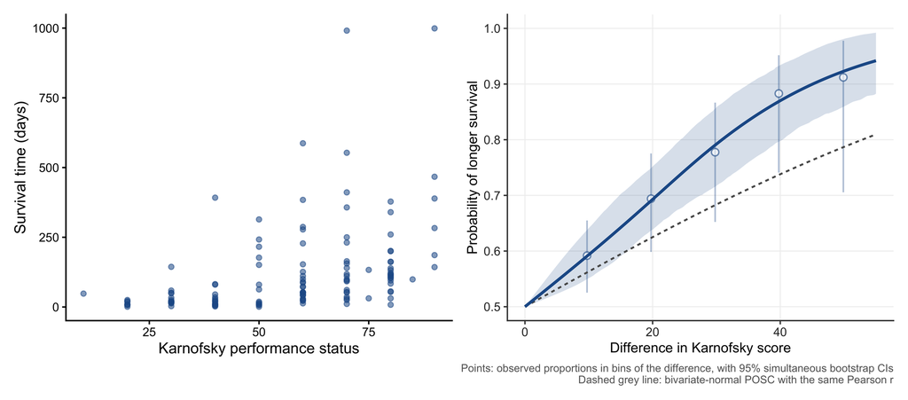

The left panel shows Karnofsky performance status and survival time in days for the patients in the Veterans Administration lung cancer trial who died during follow-up. The right panel shows the empirical POSC from `posc_emp()` with its 95% bootstrap band, the observed proportions in bins of the difference in Karnofsky score with 95% simultaneous intervals, and the normal-theory curve for the same Pearson correlation (dashed). In this example the outcome is skewed and the normal-theory curve lies below the empirical curve across the whole range.

# Research impact statement

`posc` 0.2.0 reached CRAN on 21 October 2026 (Jané 2026), with a documentation website at https://matthewbjane.com/posc/ and its source at https://github.com/MatthewBJane/posc. A longer manuscript on the website (https://matthewbjane.com/posc/paper/) derives the curve, shows that Dunlap’s statistic is its average, and documents the empirical estimator. A browser-based POSC simulator at https://matthewbjane.com/posc-simulator uses the same formulas without an R installation. The package is new, so this section describes the questions it answers. Personnel selection research reports validity coefficients routinely but rarely translates them into the probability that the higher-scoring applicant performs better. In clinical prognosis, a concordance index of 0.7 may come from a model that orders patients who are far apart on its score well and patients who are close together poorly. The curve shows which is the case. The curve also answers a question that correlation benchmarks cannot, namely how far apart two people must be before a predictor identifies the better outcome with a chosen probability. For $\rho = 0.50$ and a probability of 0.75, the answer is 1.65 standard deviations.

# AI usage disclosure

The author wrote the original package code and the original manuscript on which this paper is based. The author then used Claude, a large language model developed by Anthropic, to help extend, document and test the code, to revise text and figures, and to draft this paper from the author’s manuscript. The author specified every method, reviewed all generated code and text, and verified the results. The author checked the averaging result numerically and the empirical estimator on simulated data with known curves.

# Acknowledgements

This work received no specific funding.

# References

Ben-Shachar, Mattan S., Daniel Lüdecke, and Dominique Makowski. 2020. “Effectsize: Estimation of Effect Size Indices and Standardized Parameters.” *Journal of Open Source Software* 5 (56): 2815. https://doi.org/10.21105/joss.02815.

Dunlap, William P. 1994. “Generalizing the Common Language Effect Size Indicator to Bivariate Normal Correlations.” *Psychological Bulletin* 116 (3): 509–11. https://doi.org/10.1037/0033-2909.116.3.509.

Efron, Bradley. 1979. “Bootstrap Methods: Another Look at the Jackknife.” *The Annals of Statistics* 7 (1): 1–26. https://doi.org/10.1214/aos/1176344552.

Grissom, Robert J. 1994. “Probability of the Superior Outcome of One Treatment over Another.” *Journal of Applied Psychology* 79 (2): 314–16. https://doi.org/10.1037/0021-9010.79.2.314.

Harrell, Frank E., Robert M. Califf, David B. Pryor, Kerry L. Lee, and Robert A. Rosati. 1982. “Evaluating the Yield of Medical Tests.” *JAMA* 247 (18): 2543–46. https://doi.org/10.1001/jama.1982.03320430047030.

Jané, Matthew B. 2026. *Posc: Probability of Outcome Superiority Curves*. https://doi.org/10.32614/CRAN.package.posc.

Li, Johnson Ching-Hong, and Rory M. Waisman. 2019. “Probability of Bivariate Superiority: A Non-Parametric Common-Language Statistic for Detecting Bivariate Relationships.” *Behavior Research Methods* 51 (1): 258–79. https://doi.org/10.3758/s13428-018-1089-5.

McGraw, Kenneth O., and S. P. Wong. 1992. “A Common Language Effect Size Statistic.” *Psychological Bulletin* 111 (2): 361–65. https://doi.org/10.1037/0033-2909.111.2.361.

Montiel Olea, José Luis, and Mikkel Plagborg-Møller. 2019. “Simultaneous Confidence Bands: Theory, Implementation, and an Application to SVARs.” *Journal of Applied Econometrics* 34 (1): 1–17. https://doi.org/10.1002/jae.2656.

R Core Team. 2026. *R: A Language and Environment for Statistical Computing*. Vienna, Austria: R Foundation for Statistical Computing. https://www.R-project.org/.

Vargha, András, and Harold D. Delaney. 2000. “A Critique and Improvement of the CL Common Language Effect Size Statistics of McGraw and Wong.” *Journal of Educational and Behavioral Statistics* 25 (2): 101–32. https://doi.org/10.3102/10769986025002101.

Wickham, Hadley. 2016. *Ggplot2: Elegant Graphics for Data Analysis*. 2nd ed. New York: Springer. https://doi.org/10.1007/978-3-319-24277-4.